# Verbal Aggression Data: Motivating Questions — Instructor Answer Key

# 6 Broader Findings: What Do We Learn About Verbal Aggression Tendencies?

The Verbal Aggression survey has a 2 × 3 × 4 factorial structure (Mode × Type × Situation). The IRT parameters allow us to quantify the independent and joint contribution of each design feature to the difficulty of endorsing verbal aggression.

## 6.1 Effect of Behavior Type

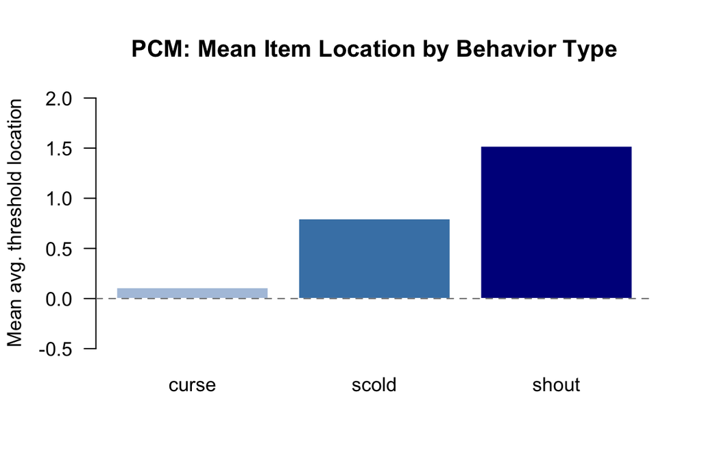

```r
type_means <- tapply(pcm_locs, item_info$Type, mean)
ord_type   <- order(type_means)

barplot(type_means[ord_type],
        col    = c("lightsteelblue", "steelblue", "darkblue"),
        main   = "PCM: Mean Item Location by Behavior Type",
        ylab   = "Mean avg. threshold location",
        ylim   = c(-0.5, max(type_means) + 0.5),
        border = "white", las = 1)
abline(h = 0, lty = 2, col = "grey50")
```

The design expectation—that curse items are easiest, scold items intermediate, and shout items hardest to endorse—is confirmed by the data: the three behavior types fall in the intended order on the latent trait continuum. The difference between curse and shout is substantial (roughly 1.41 logits under the PCM).

## 6.2 Effect of Behavior Mode

```r
mode_means <- tapply(pcm_locs, item_info$Mode, mean)
cat(sprintf("Mean PCM location — Want items: %+.3f\n", mode_means["want"]))
```

```
## Mean PCM location — Want items: +0.556
```

```r
cat(sprintf("Mean PCM location — Do items:   %+.3f\n", mode_means["do"]))
```

```
## Mean PCM location — Do items:   +1.060
```

```r
cat(sprintf("Do - Want difference:            %+.3f logits\n",
            mode_means["do"] - mode_means["want"]))
```

```
## Do - Want difference:            +0.504 logits
```